# Praca domowa 2

Antoni Rakowski

## Dane

Dane wykorzystane w Pracy domowej 2 opisują wycenę nieruchmości. Każda obserwacja jest pewną nieruchmością, która posiada informacje takie jak powierzchnia, liczba pokoi, liczba łazienek i wiele więcj. Opis wszystkich kolumn w pliku `README.md`.

## Zadanie 1

Jak wygląda rozkład ceny nieruchomości w poszczególnych kodach pocztowych na przestrzeni lat? Rozważamy kody pocztowe, które mają więcej niż 280 posiadłości.

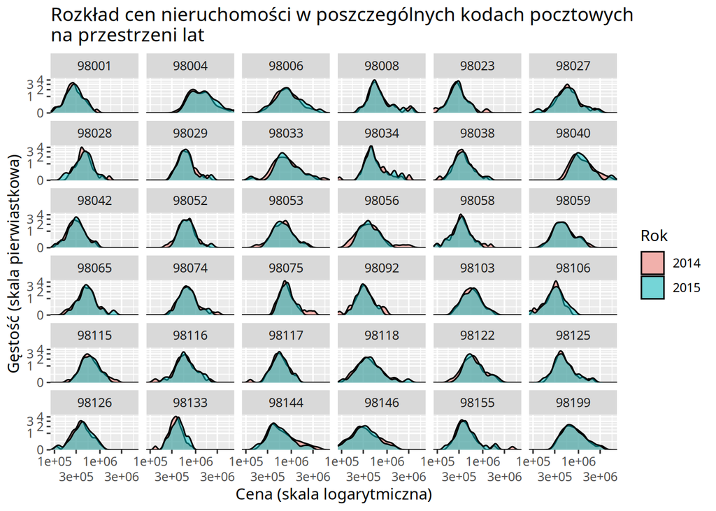

```r
# Tu umieść kod do wygenerowania odpowiedzi do zadania.
zipcodes <- df %>%
  group_by(zipcode) %>%
  summarise(n_of_properties = n()) %>%
  ungroup() %>%
  filter(n_of_properties > 280) %>%
  pull(zipcode)

df %>%
  filter(zipcode %in% zipcodes) %>%
  mutate(year = format(as.POSIXct(date, format = "%Y%m%dT%H%M%S"), "%Y")) %>%
  group_by(zipcode, year) %>%
  ggplot(aes(x = price, fill = as.factor(year))) +
  geom_density(alpha = 0.5) +
  facet_wrap(~ zipcode) +
  scale_y_sqrt(expand = expansion(mult = 0), guide = guide_axis(n.dodge = 2)) +
  scale_x_log10(expand = expansion(mult = 0), guide = guide_axis(n.dodge = 2)) +
  labs(title = "Rozkład cen nieruchomości w poszczególnych kodach pocztowych\nna przestrzeni lat", # nolint
       x = "Cena (skala logarytmiczna)",
       y = "Gęstość (skala pierwiastkowa)", fill = "Rok")
```

**Komentarz: Dla wszystkich kodów pocztowych rozkład w 2014 i 2015 jest bardzo podobny. Z góry przepraszam za niejednoliniowe ułożenie znaczników na osiach, ale niestety zmiana na html “ściska” wszystkie zdjęcia. Mimo że, wykres z “normalnym” ułożeniem wskaźników wyglądał w porządku, to po zmianie na html znaczniki zaczęły na siebie najeżdzać, a więc byłem zmuszony dokonać tej modyfikacji.**

## Zadanie 2

Czy jest różnica w rozkładzie ceny nierchomości od powierzchni mieszkalnej uwzględniając podział na nieruchomości z piwnicą i bez?

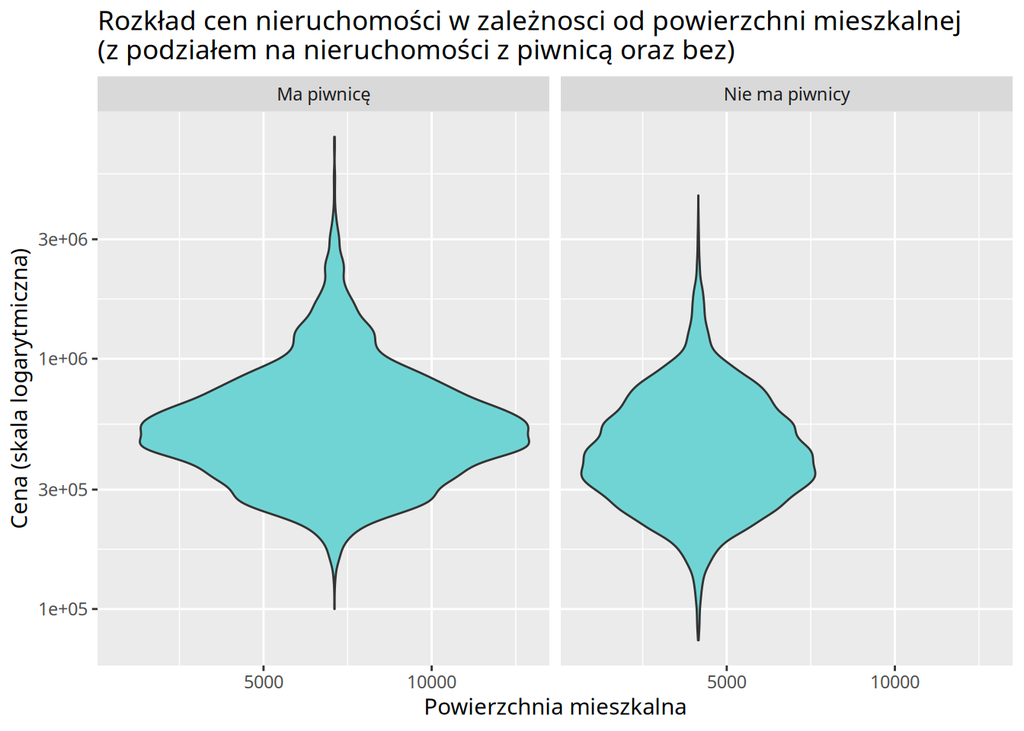

```r
# Tu umieść kod do wygenerowania odpowiedzi do zadania.
df %>%
  mutate(has_basement = case_when(sqft_basement == 0 ~ "Nie ma piwnicy",
                                  TRUE ~ "Ma piwnicę")) %>%
  ggplot(aes(x = sqft_living, y = price)) +
  scale_y_log10() +
  geom_violin(fill = "#71d4d4") +
  facet_wrap(~ has_basement) +
  labs(title = "Rozkład cen nieruchomości w zależnosci od powierzchni mieszkalnej\n(z podziałem na nieruchomości z piwnicą oraz bez)", # nolint
       y = "Cena (skala logarytmiczna)",
       x = "Powierzchnia mieszkalna")
```

**Komentarz: Wykres pokazuje, że nieruchomości z piwnicą mają większy zakres cen niż te bez piwnicy.**

## Zadanie 3

Jaka jest zależność pomiędzy jakością wykończenia nieruchomości a liczbą pięter?

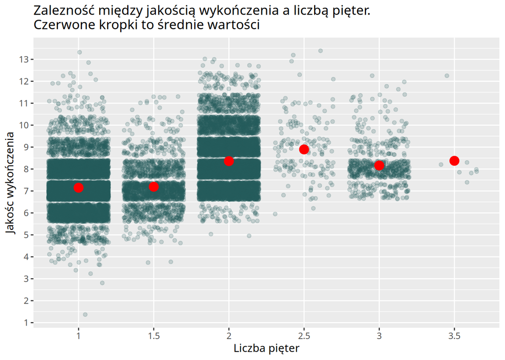

```r
# Tu umieść kod do wygenerowania odpowiedzi do zadania.
df %>%
  ggplot(aes(x = factor(floors), y = grade)) +
  geom_jitter(alpha = 0.2, color = "#245b5b") +
  scale_y_continuous(breaks = seq(1, 13, 1)) +
  labs(title = "Zalezność między jakością wykończenia a liczbą pięter.\nCzerwone kropki to średnie wartości", #nolint
       y = "Jakośc wykończenia", x = "Liczba pięter") +
  stat_summary(fun = mean, geom = "point", size = 4, color = "red")
```

**Komentarz: Dla pięter 1, 1.5, 2, 2.5 średnia jakość wykończenia rośnie wraz z ilością pięter. Dla 3 spada, a dla 3.5 ponownie wzrasta. Największa średnia jest dla 2.5 pięter.**

## Zadanie 4

Jaka jest zależność między powierzchnią mieszkalną nieruchomości a powierzchnią gruntu w podziale na liczbę sypialni?

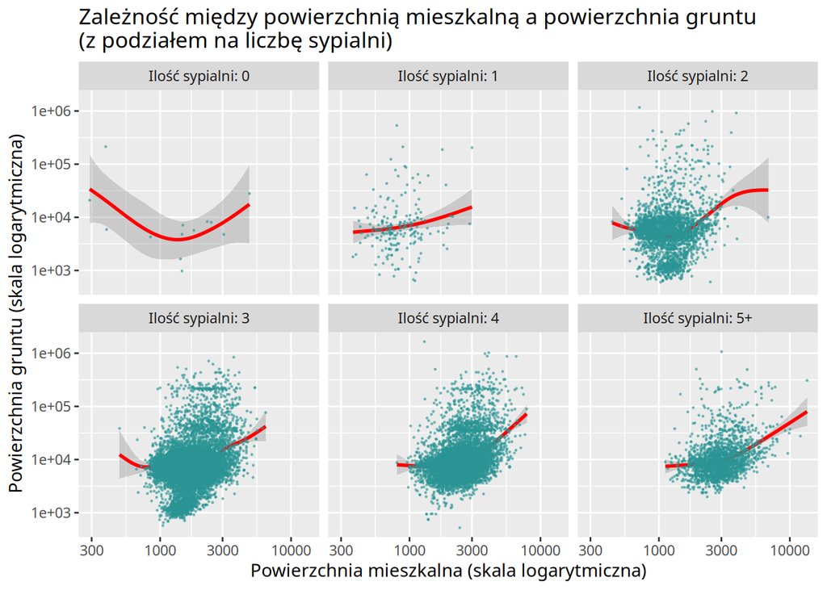

```r
# Tu umieść kod do wygenerowania odpowiedzi do zadania.
# df %>%
#   pull(bedrooms) %>%
#   quantile(0.9)
# na tej podstawie i na podstawie małej ilości
# danych dla 5+ sypialni grupuję te nieruchomości

df %>%
  mutate(bedrooms = case_when(bedrooms > 4 ~ "Ilość sypialni: 5+",
                              TRUE ~ paste0("Ilość sypialni: ", as.character(bedrooms)))) %>% # nolint
  ggplot(aes(y = sqft_lot, x = sqft_living)) +
  facet_wrap(~ bedrooms) +
  geom_smooth(method = "gam", formula = y ~ s(x), col = "red") +
  scale_y_log10() +
  scale_x_log10() +
  geom_point(color = "#2a9393", alpha = 0.5, size = 0.2) +
  labs(title = "Zależność między powierzchnią mieszkalną a powierzchnia gruntu\n(z podziałem na liczbę sypialni)", #nolint
       y = "Powierzchnia gruntu (skala logarytmiczna)",
       x = "Powierzchnia mieszkalna (skala logarytmiczna)")
```

**Komentarz: Nie ma żadnych silnych, trywialnych zależności (np. silnych zależności liniowch), aczkolwiek w miejscach z dużą ilością punktów widać tendencję wzrostową, jednakowoż jest to bardzo słaba zależność**

## Zadanie 5

Rozważmy tylko nieruchomości, które miały remont. W której dekadzie było najwięcej przeprowadzonych remontów? Czy w poszczególnych dekadach jest porównywalny procent nieruchmości dla każdej wartości miary jakości i wykończenia nieruchomości?

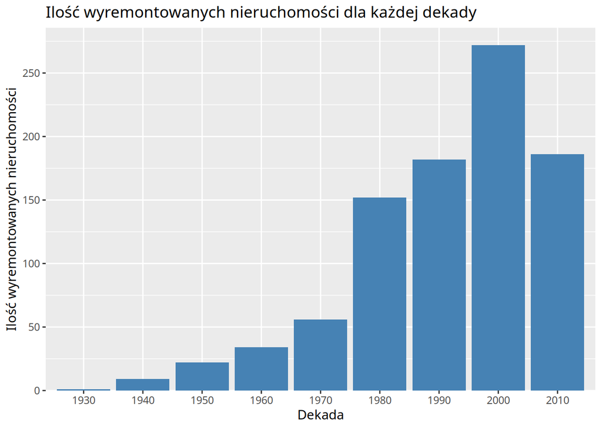

```r
# Tu umieść kod do wygenerowania odpowiedzi do zadania.
tmp <- df %>%
  filter(yr_renovated != 0) %>%
  mutate(decade_renovated = 10 * floor(yr_renovated / 10))

tmp1 <- tmp %>%
  group_by(decade_renovated) %>%
  summarise(n = n()) %>%
  ungroup()

ggplot(tmp1, aes(x = as.factor(decade_renovated), y = n)) +
  geom_col(fill = "steelblue") +
  scale_y_continuous(expand = expansion(mult = c(0, 0.05)),
                     breaks = seq(0, 300, 50)) +
  scale_x_discrete(expand = expansion(mult = c(0.08, 0.08))) +
  labs(title = "Ilość wyremontowanych nieruchomości dla każdej dekady",
       x = "Dekada", y = "Ilość wyremontowanych nieruchomości")
```

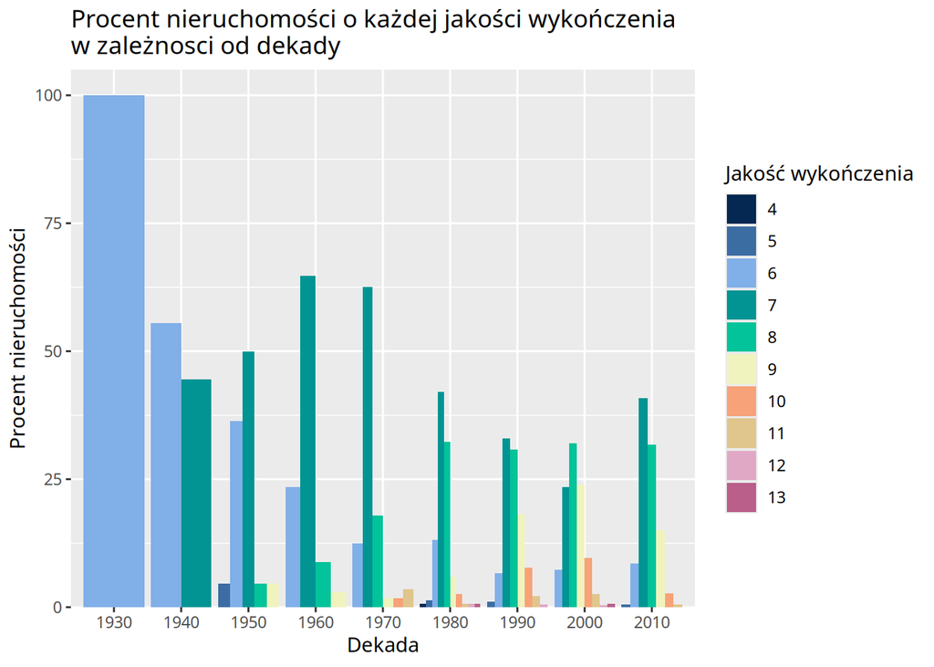

```r
tmp %>%
  group_by(decade_renovated, grade) %>%
  summarise(n = n()) %>%
  ungroup() %>%
  left_join(tmp1, by = "decade_renovated") %>%
  mutate(percent = 100 * n.x / n.y) %>%
  ggplot(aes(x = as.factor(decade_renovated),
             y = percent, fill = as.factor(grade))) +
  geom_col(position = "dodge") +
  scale_x_discrete(expand = expansion(mult = c(0.08, 0.08))) +
  scale_y_continuous(expand = expansion(mult = c(0, 0.05))) +
  labs(title = "Procent nieruchomości o każdej jakości wykończenia\nw zależnosci od dekady", #nolint
       x = "Dekada", y = "Procent nieruchomości", fill = "Jakość wykończenia") +
  scale_fill_manual(values = c("#042851", "#3b6ca2", "#81afe8", "#019493", "#02C39A", "#F0F3BD", "#F7A278", "#E0C68C", "#e0a8c5", "#B95F89")) #nolint
```

**Komentarz: Najwięcej remontów było w latach 2000. Na wykresach procenty nieruchomości nie są porównywalne dla każdej dekady, aczkolwiek dla pierwszych kilku dekad posiadamy bardzo mało danych. W późniejszych dekadach (1980+), z których mamy znacznie większą ilość danych procenty te stają się porównywalne. Nie jesteśmy w stanie stwierdzić czy wcześniej też były porównywalne czy nie w związku z deficytem danych.**

## Zadanie 6

Jak prezentuje się wartość minimalna, średnia i maksymalna ceny nieruchmości w podziele na rok budowy nieruchomości.

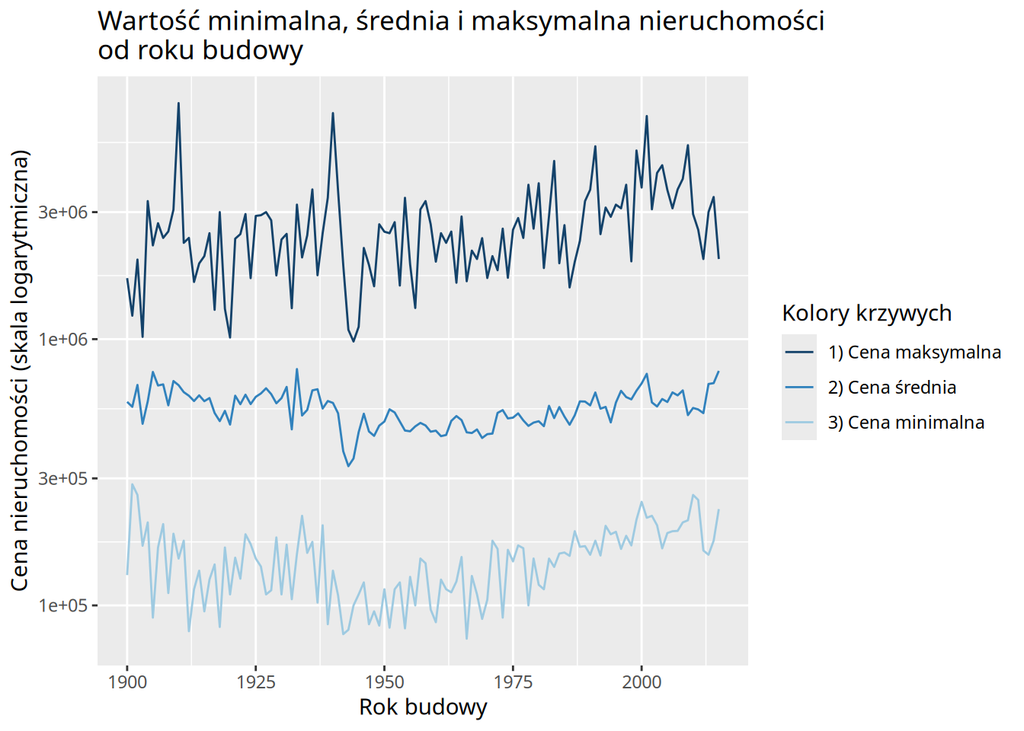

```r
# Tu umieść kod do wygenerowania odpowiedzi do zadania.
tmp <- df %>%
  group_by(yr_built)  %>%
  summarise(min_price = min(price), mean_price = mean(price),
            max_price = max(price)) %>%
  ungroup()

ggplot(tmp, aes(x = yr_built)) +
  geom_line(aes(y = max_price, color = "1) Cena maksymalna")) +
  geom_line(aes(y = min_price, color = "3) Cena minimalna")) +
  geom_line(aes(y = mean_price, color = "2) Cena średnia")) +
  scale_y_log10() +
  scale_color_manual(values = c("3) Cena minimalna" = "#9ECAE1",
                                "2) Cena średnia" = "#3182BD",
                                "1) Cena maksymalna" = "#13426a")) +
  labs(title = "Wartość minimalna, średnia i maksymalna nieruchomości\nod roku budowy", #nolint
       x = "Rok budowy", y = "Cena nieruchomości (skala logarytmiczna)",
       color = "Kolory krzywych")
```

```r
# cor(tmp$mean_price, tmp$min_price, method = "spearman")
# cor(tmp$min_price, tmp$max_price, method = "spearman")
# cor(tmp$mean_price, tmp$max_price, method = "spearman")

# cor(tmp$mean_price, tmp$min_price)
# cor(tmp$min_price, tmp$max_price)
# cor(tmp$mean_price, tmp$max_price)
```

**Komentarz: Wszystkie trzy parametry doznają intensywnych fluktuacji na przestrzeni lat. Są one ze sobą średnio skorelowane wg. korelacji Spearmana (wszystkie wzajemne korelacje mieszczą się w przedziale [0.4, 0.5]). Wg. korelacji Pearsona średnia cena jest średnio skorelowana z pozostałymi (korelacje z przedziału [0.4, 0.5]), a cena maksymalna i minimalna są słabo skorelowane (ok. 0.25).**